# Final Project: Submission

#### By Ethan Nguonly, Mohamed Sondo, and Brian Truong

# Intro

HR analytics is a field that continues to grow and one very important metric of interest is employee atrition. Attrition is the rate at which employees leave a company, usually for a variety of reasons. The goal of this project is to analyze a dataset of employees and whether they left the company or not. The dataset that we are working with is 2019 HR Employee Attrition from Kaggle (https://www.kaggle.com/james2919/hr-employee-attrition). If we are able to successfully model the key predictors of employee attrition, companies will be able to better target and retain talent, thus reducing the need to hire and retrain new employees.

McCurr Healthcare Consultancy is an MNC that has thousands of employees spread out across the globe. The company believes in hiring the best talent available and retaining them for as long as possible. A huge amount of resources is spent on retaining existing employees through various initiatives. The Head of People Operations wants to bring down the cost of retaining employees. For this, he proposes limiting the incentives to only those employees who are at risk of attrition We have been asked to identify patterns in characteristics of employees who leave the organization. Also, We have to use this information to predict if an employee is at risk of attrition. This information will be used to target them with incentives.

## **Objective:**

- To identify the different factors that drive attrition
- To make a model to predict the attrition

## **Dataset:Description of data source**

The data source used for this project can be found here: https://www.kaggle.com/james2919/hr-employee-attrition

It has the following features:

- EmployeeNumber (Int) - Employee Identifier
- Attrition (String) - Did the employee attrite?
  - "Yes"
  - "No"

*Demographic*

- Age - Age of the employee
- Education (Int)
  - 1 - Below College
  - 2 - CollegeBachelor
  - 4 - Master
  - 5 - Doctor
- EducationField (String) - Field of Education
  - "Life Sciences"
  - "Other"
  - "Medical"
  - "Marketing"
  - "Technical Degree"
  - "Human Resources"
- Gender (String)
  - "Male"
  - "Female"
- MaritalStatus (String)
  - "Single"
  - "Married"
  - "Divorced"
- NumCompaniesWorked (Int) - Number of companies worked at
- Over18 (String) - Over 18 years of age?
  - "Y"
  - "N" *There are no N values in the dataset*

*Compensation*

- MonthlyIncome (Int) - Monthly Salary
- PercentSalaryHike (Int) - The percentage increase in salary last year
- StockOptionLevel (Int) - Stock Option Level

*Unknown what these actually represent*

- HourlyRate (Int) - Data description not available**
- DailyRate (Int) - Data description not available**
- MonthlyRate (Int) - Data description not available**

*Position information*

- BusinessTravel (String) - Travel commitments for the job
  - "Non-Travel"
  - "Travel_Rarely"
  - "Travel_Frequently"
- Department (String) - Employee Department
  - "Sales"
  - "Research & Development"
  - "Human Resources"
- DistanceFromHome (Int) - Distance from work to home (in km)
- JobInvolvement (Int)
  - 1 - Low
  - 2 - Medium
  - 3 - High
  - 4 - Very High
- JobLevel (Int) - Level of job (1 to 5)
- JobRole (String) - Job Roles
  - "Sales Executive"
  - "Research Scientist"
  - "Laboratory Technician"
  - "Manufacturing Director"
  - "Healthcare Representative"
  - "Manager"
  - "Sales Representative"
  - "Research Director"
  - "Human Resources"
- StandardHours (Int) - Standard Hours *All of these are 80*
- OverTime (String)
  - "Yes"
  - "No"

*History with company*

- PerformanceRating (Int)
  - 1 - Low
  - 2 - Good
  - 3 - Excellent
  - 4 - Outstanding
- TrainingTimesLastYear (Int) - Number of training attended last year
- TotalWorkingYears (Int) - Total years worked
- YearsAtCompany (Int) - Years at Company
- YearsInCurrentRole (Int) - Years in the current role
- YearsSinceLastPromotion (Int) - Years since the last promotion
- YearsWithCurrManager (Int) - Years with the current manager

*Job satisfaction*

- EnvironmentSatisfaction (Int)
- JobSatisfaction (Int)
- WorkLifeBalance (Int
- RelationshipSatisfaction (Int)
  - 1 - Low
  - 2 - Medium
  - 3 - High
  - 4 - Very High

## Objective :

- To identify the different factors that drive attrition
- To make a model to predict if an employee will attrite or not
- **The company want the Recall to be maximized**, the greater the Recall, the higher the chances of minimizing false negatives. Hence, the focus should be on increasing Recall (minimizing the false negatives) or in other words identifying the true positives (i.e. Class 1) very well, so that the company can provide incentives to control attrition rate especially for top-performers. This would help in optimizing the overall project cost towards retaining the best talent.

### Import the necessary libraries

```python
# !pip install pandas-profiling
import json
import numpy as np
import pandas as pd
import matplotlib.pyplot as plt
from sklearn import metrics
from sklearn import preprocessing
from sklearn.linear_model import LogisticRegression
from sklearn.metrics import confusion_matrix, roc_curve, classification_report
from sklearn.metrics import confusion_matrix, classification_report, precision_recall_curve,recall_score
from sklearn.model_selection import train_test_split
from sklearn.neighbors import KNeighborsClassifier
from sklearn.tree import DecisionTreeClassifier, plot_tree, export_text
from sklearn.feature_selection import SelectKBest
from sklearn.feature_selection import f_classif
from sklearn.decomposition import PCA
from sklearn.feature_selection import RFE
from sklearn.ensemble import ExtraTreesClassifier
import seaborn as sns
from pandas_profiling import ProfileReport
#to scale the data using z-score
from sklearn.preprocessing import StandardScaler
from sklearn.model_selection import GridSearchCV
import copy

from sklearn import tree
from sklearn.ensemble import BaggingClassifier
from sklearn.ensemble import RandomForestClassifier


%matplotlib inline

#to ignore warnings
import warnings
warnings.filterwarnings("ignore")
```

```python
#!pip install pandas-profiling
```

### Read the dataset

```python
# load data into dataframe
df = pd.read_csv(r'data/HR_Employee_Attrition_Dataset.csv')

# create dataframe copy for additional feature selection
pca_df = copy.deepcopy(df)
```

```python
# profile = ProfileReport(df, title="Pandas Profiling Report")
# profile.to_file("HR_Employee_Attrition_Data_Profile.html")
```

```python
# show dataframe
df.head()
```

|  | EmployeeNumber | Attrition | Age | BusinessTravel | DailyRate | Department | DistanceFromHome | Education | EducationField | EnvironmentSatisfaction | ... | RelationshipSatisfaction | StandardHours | StockOptionLevel | TotalWorkingYears | TrainingTimesLastYear | WorkLifeBalance | YearsAtCompany | YearsInCurrentRole | YearsSinceLastPromotion | YearsWithCurrManager |
| --- | --- | --- | --- | --- | --- | --- | --- | --- | --- | --- | --- | --- | --- | --- | --- | --- | --- | --- | --- | --- | --- |
| 0 | 1 | Yes | 41 | Travel_Rarely | 1102 | Sales | 1 | 2 | Life Sciences | 2 | ... | 1 | 80 | 0 | 8 | 0 | 1 | 6 | 4 | 0 | 5 |
| 1 | 2 | No | 49 | Travel_Frequently | 279 | Research & Development | 8 | 1 | Life Sciences | 3 | ... | 4 | 80 | 1 | 10 | 3 | 3 | 10 | 7 | 1 | 7 |
| 2 | 3 | Yes | 37 | Travel_Rarely | 1373 | Research & Development | 2 | 2 | Other | 4 | ... | 2 | 80 | 0 | 7 | 3 | 3 | 0 | 0 | 0 | 0 |
| 3 | 4 | No | 33 | Travel_Frequently | 1392 | Research & Development | 3 | 4 | Life Sciences | 4 | ... | 3 | 80 | 0 | 8 | 3 | 3 | 8 | 7 | 3 | 0 |
| 4 | 5 | No | 27 | Travel_Rarely | 591 | Research & Development | 2 | 1 | Medical | 1 | ... | 4 | 80 | 1 | 6 | 3 | 3 | 2 | 2 | 2 | 2 |

5 rows × 34 columns

### Printing the information

```python
df.info()
```

```
<class 'pandas.core.frame.DataFrame'>
RangeIndex: 2940 entries, 0 to 2939
Data columns (total 34 columns):
 #   Column                    Non-Null Count  Dtype
---  ------                    --------------  -----
 0   EmployeeNumber            2940 non-null   int64
 1   Attrition                 2940 non-null   object
 2   Age                       2940 non-null   int64
 3   BusinessTravel            2940 non-null   object
 4   DailyRate                 2940 non-null   int64
 5   Department                2940 non-null   object
 6   DistanceFromHome          2940 non-null   int64
 7   Education                 2940 non-null   int64
 8   EducationField            2940 non-null   object
 9   EnvironmentSatisfaction   2940 non-null   int64
```

[output cut: 26 more lines]

**Observations:**

- Employee number is an identifier which is unique for each employee and we can drop this column as it would not add any value to our analysis.
- Over18 and StandardHours have only 1 unique value. These column will not add any value to our model hence we can drop them.
- On the basis of number of unique values in each column and the data description, we can identify the continuous and categorical columns in the data.

Let's drop the columns mentioned above and define lists for numerical and categorical columns to apply explore them separately.

```python
#dropping the columns
df=df.drop(['EmployeeNumber','Over18','StandardHours'],axis=1)
```

```python
#Creating numerical columns
num_cols=['DailyRate','Age','DistanceFromHome','MonthlyIncome','MonthlyRate','PercentSalaryHike','TotalWorkingYears',
          'YearsAtCompany','NumCompaniesWorked','HourlyRate',
          'YearsInCurrentRole','YearsSinceLastPromotion','YearsWithCurrManager','TrainingTimesLastYear']

#Creating categorical variables
cat_cols= ['Attrition','OverTime','BusinessTravel', 'Department','Education', 'EducationField','JobSatisfaction','EnvironmentSatisfaction','WorkLifeBalance',
           'StockOptionLevel','Gender', 'PerformanceRating', 'JobInvolvement','JobLevel', 'JobRole', 'MaritalStatus','RelationshipSatisfaction']
```

### Univariate analysis of numerical columns

```python
#Checking summary statistics
df[num_cols].describe().T
```

|  | count | mean | std | min | 25% | 50% | 75% | max |
| --- | --- | --- | --- | --- | --- | --- | --- | --- |
| DailyRate | 2940.0 | 802.485714 | 403.440447 | 102.0 | 465.0 | 802.0 | 1157.0 | 1499.0 |
| Age | 2940.0 | 36.923810 | 9.133819 | 18.0 | 30.0 | 36.0 | 43.0 | 60.0 |
| DistanceFromHome | 2940.0 | 9.192517 | 8.105485 | 1.0 | 2.0 | 7.0 | 14.0 | 29.0 |
| MonthlyIncome | 2940.0 | 6502.931293 | 4707.155770 | 1009.0 | 2911.0 | 4919.0 | 8380.0 | 19999.0 |
| MonthlyRate | 2940.0 | 14313.103401 | 7116.575021 | 2094.0 | 8045.0 | 14235.5 | 20462.0 | 26999.0 |
| PercentSalaryHike | 2940.0 | 15.209524 | 3.659315 | 11.0 | 12.0 | 14.0 | 18.0 | 25.0 |
| TotalWorkingYears | 2940.0 | 11.279592 | 7.779458 | 0.0 | 6.0 | 10.0 | 15.0 | 40.0 |
| YearsAtCompany | 2940.0 | 7.008163 | 6.125483 | 0.0 | 3.0 | 5.0 | 9.0 | 40.0 |
| NumCompaniesWorked | 2940.0 | 2.693197 | 2.497584 | 0.0 | 1.0 | 2.0 | 4.0 | 9.0 |
| HourlyRate | 2940.0 | 65.891156 | 20.325969 | 30.0 | 48.0 | 66.0 | 84.0 | 100.0 |
| YearsInCurrentRole | 2940.0 | 4.229252 | 3.622521 | 0.0 | 2.0 | 3.0 | 7.0 | 18.0 |
| YearsSinceLastPromotion | 2940.0 | 2.187755 | 3.221882 | 0.0 | 0.0 | 1.0 | 3.0 | 15.0 |
| YearsWithCurrManager | 2940.0 | 4.123129 | 3.567529 | 0.0 | 2.0 | 3.0 | 7.0 | 17.0 |
| TrainingTimesLastYear | 2940.0 | 2.799320 | 1.289051 | 0.0 | 2.0 | 3.0 | 3.0 | 6.0 |

**Observations:**

- **Average employee age is around 37 years**. It has a high range, from 18 years to 60, indicating good age diversity in the organization.
- **At least 50% of the employees live within a 7 km radius** from the organization. However there are some extreme values, seeing as the maximum value is 29 km.
- **The average monthly income of an employee is USD 6500.** It has a high range of values from 1K-20K USD, which is to be expected for any organization's income distribution. There is a big difference between the 3rd quartile value (around USD 8400) and the maximum value (nearly USD 20000), showing that the **company's highest earners have a disproportionately large income** in comparison to the rest of the employees. Again, this is fairly common in most organizations.
- **Average salary hike of an employee is around 15%.** At least 50% of employees got a salary hike 14% or less, with the maximum salary hike being 25%.
- Average number of years an employee is associated with the company is 7.
- **On average, the number of years since an employee got a promotion is 2.18**. The majority of employees have been promoted since the last year.

Exploration of Numerircal variables in more depth by observing their distributions

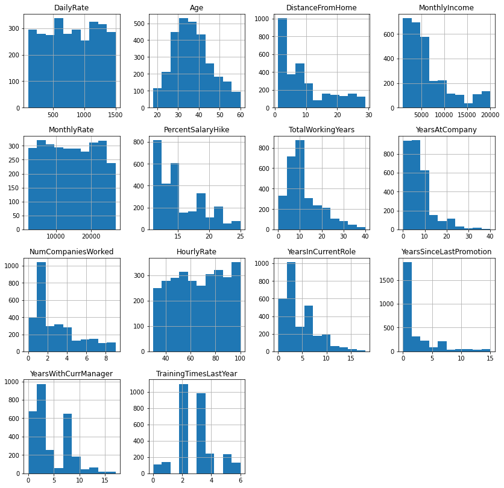

```python
#creating histograms
df[num_cols].hist(figsize=(14,14))
plt.show()
```

**Observations:**

### Univariate analysis for categorical variables

```python
#Printing the % sub categories of each category
for i in cat_cols:
    print(df[i].value_counts(normalize=True))
    print('*'*40)
```

```
No     0.838776
Yes    0.161224
Name: Attrition, dtype: float64
No     0.717007
Yes    0.282993
Name: OverTime, dtype: float64
Travel_Rarely        0.709524
Travel_Frequently    0.188435
Non-Travel           0.102041
Name: BusinessTravel, dtype: float64
Research & Development    0.653741
Sales                     0.303401
Human Resources           0.042857
Name: Department, dtype: float64
3    0.389116
4    0.270748
2    0.191837
1    0.115646
5    0.032653
Name: Education, dtype: float64
Life Sciences       0.412245
Medical             0.315646
Marketing           0.108163
Technical Degree    0.089796
Other               0.055782
Human Resources     0.018367
Name: EducationField, dtype: float64
4    0.312245
3    0.300680
1    0.196599
2    0.190476
Name: JobSatisfaction, dtype: float64
3    0.308163
4    0.303401
2    0.195238
1    0.193197
Name: EnvironmentSatisfaction, dtype: float64
3    0.607483
2    0.234014
4    0.104082
```

[output cut: 28 more lines]

```
Healthcare Representative    0.089116
Manager                      0.069388
Sales Representative         0.056463
Research Director            0.054422
Human Resources              0.035374
Name: JobRole, dtype: float64
Married     0.457823
Single      0.319728
Divorced    0.222449
Name: MaritalStatus, dtype: float64
3    0.312245
4    0.293878
2    0.206122
1    0.187755
Name: RelationshipSatisfaction, dtype: float64
```

**Observations:**

- **The employee attrition rate is 16%.**
- **Around 28% of the employees are working overtime.** This number appears to be on the higher side, and might indicate a stressed employee work-life.
- 71% of the employees have traveled rarely, while around 19% have to travel frequently.
- Around 73% of the employees come from an educational background in the Life Sciences and Medical fields.
- Over 65% of employees work in the Research & Development department of the organization.
- **Nearly 40% of the employees have low (1) or medium-low (2) job satisfaction** and environment satisfaction in the organization, indicating that the morale of the company appears to be somewhat low.
- **Over 30% of the employees show low (1) to medium-low (2) job involvement.**
- Over 80% of the employees either have none or very less stock options.
- **In terms of performance ratings, none of the employees have rated lower than 3 (excellent).** About 85% of employees have a performance rating equal to 3 (excellent), while the remaining have a rating of 4 (outstanding). This could either mean that the majority of employees are top performers, or the more likely scenario is that the organization could be highly lenient with its performance appraisal process.

### Bivariate and Multivariate analysis

**Analysis of different categorical and numerical variables.**

**Let's now check how does attrition rate is related with other categorical variables**

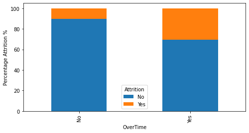

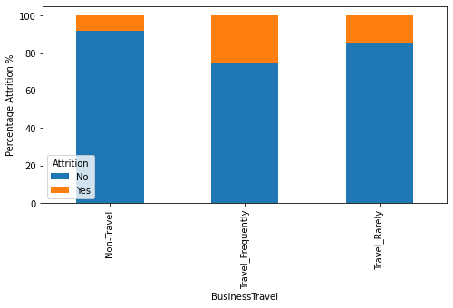

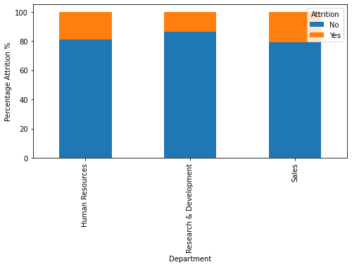

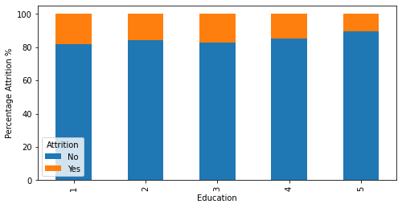

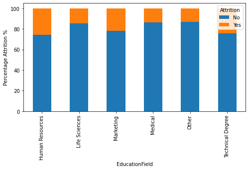

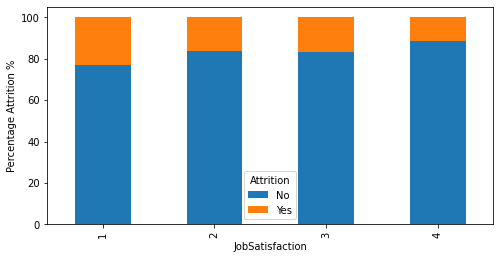

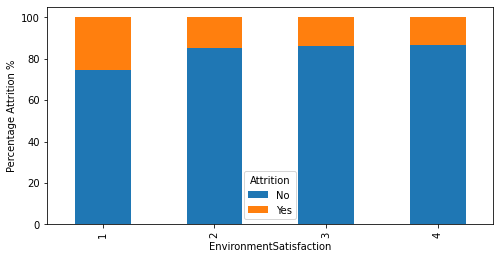

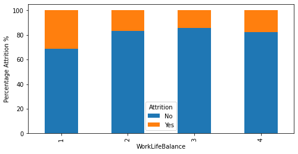

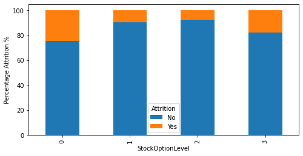

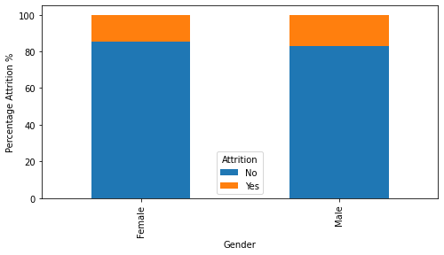

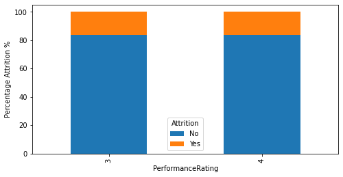

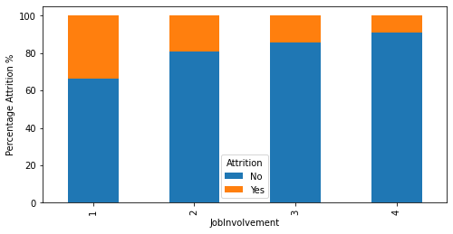

[4 more figures not shown]

```python
for i in cat_cols:
    if i!='Attrition':
        (pd.crosstab(df[i],df['Attrition'],normalize='index')*100).plot(kind='bar',figsize=(8,4),stacked=True)
        plt.ylabel('Percentage Attrition %')
```

**Observations:**

- **Employees working overtime have more than a 30% chance of attrition**, which is very high compared to the 10% chance of attrition for employees who do not work extra hours.
- As seen earlier, the majority of employees work for the R&D department. The chance of attrition there is ~15%
- **Employees working as sales representatives have an attrition rate of around 40%** while HRs and Technicians have an attrition rate of around 25%. The sales and HR departments have higher attrition rates in comparison to an academic department like Research & Development, an observation that makes intuitive sense keeping in mind the differences in those job profiles. The high-pressure and incentive-based nature of Sales and Marketing roles may be contributing to their higher attrition rates.
- **The lower the employee's job involvement, the higher their attrition chances appear to be, with 1-rated JobInvolvement employees attriting at 35%.** The reason for this could be that employees with lower job involvement might feel left out or less valued and have already started to explore new options, leading to a higher attrition rate.
- **Employees at a lower job level also attrite more,** with 1-rated JobLevel employees showing a nearly 25% chance of attrition. These may be young employees who tend to explore more options in the initial stages of their careers.
- **A low work-life balance rating clearly leads employees to attrite**; 30% of those in the 1-rated category show attrition.

**Let's check the relationship between attrition and Numerical variables**

```python
#Mean of numerical variables grouped by attrition
df.groupby(['Attrition'])[num_cols].mean()
```

| Attrition | DailyRate | Age | DistanceFromHome | MonthlyIncome | MonthlyRate | PercentSalaryHike | TotalWorkingYears | YearsAtCompany | NumCompaniesWorked | HourlyRate | YearsInCurrentRole | YearsSinceLastPromotion | YearsWithCurrManager | TrainingTimesLastYear |
| --- | --- | --- | --- | --- | --- | --- | --- | --- | --- | --- | --- | --- | --- | --- |
| No | 812.504461 | 37.561233 | 8.915653 | 6832.739659 | 14265.779400 | 15.231144 | 11.862936 | 7.369019 | 2.645580 | 65.952149 | 4.484185 | 2.234388 | 4.367397 | 2.832928 |
| Yes | 750.362869 | 33.607595 | 10.632911 | 4787.092827 | 14559.308017 | 15.097046 | 8.244726 | 5.130802 | 2.940928 | 65.573840 | 2.902954 | 1.945148 | 2.852321 | 2.624473 |

**Observations:**

```python
# What's Majority class of the datasets
cnts = df["Attrition"].value_counts()
np.argmax(cnts)
```

```
0
```

### Let's check the relationship between different numerical variables

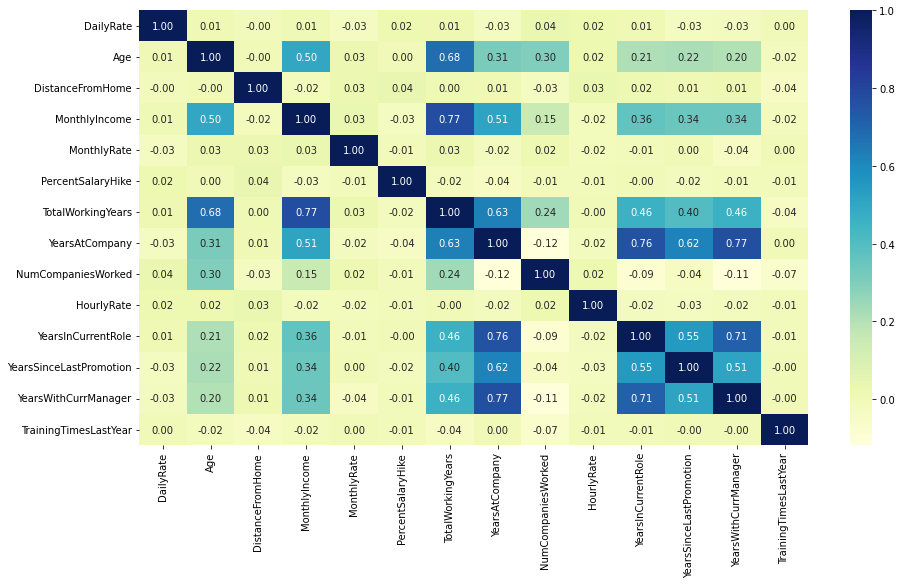

```python
#plotting the correlation between numerical variables
plt.figure(figsize=(15,8))
sns.heatmap(df[num_cols].corr(),annot=True, fmt='0.2f', cmap='YlGnBu')
```

**Observations:**

- **Total work experience, monthly income, years at company and years with current manager are highly correlated with each other and with employee age** which is easy to understand as these variables show an increase with age for most employees.
- Years at company and years in current role are correlated with years since last promotion which means that the company is not giving promotions at the right time.

## Additional Feature Selection Techniques

```python
# dropping the columns
pca_df=pca_df.drop(['EmployeeNumber','Over18','StandardHours'],axis=1)

# convert categorical variables to numbers
pca_df['Attrition'] = pca_df['Attrition'].map({"No": 0, "Yes": 1})
pca_df['EducationField'] = pca_df['EducationField'].map({"Life Sciences": 0, "Other": 1, "Medical": 2,
                                                  "Marketing": 3, "Technical Degree": 4, "Human Resources": 5})
pca_df["Gender"] = pca_df["Gender"].map({"Male": 0, "Female": 1})
pca_df["MaritalStatus"] = pca_df["MaritalStatus"].map({"Single": 0, "Married": 1, "Divorced": 2})
pca_df["BusinessTravel"] = pca_df["BusinessTravel"].map({"Non-Travel": 0, "Travel_Rarely": 1, "Travel_Frequently": 2})
pca_df["Department"] = pca_df["Department"].map({"Sales": 0, "Research & Development": 1, "Human Resources": 2})
pca_df["JobRole"] = pca_df["JobRole"].map({"Sales Executive": 0, "Research Scientist": 1, "Laboratory Technician": 2,
                                   "Manufacturing Director": 3, "Healthcare Representative": 4, "Manager": 5,
                                   "Sales Representative": 6, "Research Director": 7, "Human Resources": 8})
pca_df['OverTime'] = pca_df['OverTime'].map({"No": 0, "Yes": 1})

# format dataframe values for feature selection
feature_names = pca_df.columns[1:]
array = pca_df.values
X = array[:,1:len(pca_df.columns)]
Y = array[:,0]
Y = Y.astype('int')
```

```python
# Feature Selection with Univariate Statistical Tests
test = SelectKBest(score_func=f_classif, k=4)
fit = test.fit(X, Y)
# summarize scores
np.set_printoptions(precision=3)
print(fit.scores_)
selected_features_indices = fit.scores_.argsort()[-4:][::-1]
print("Features with Highest Impact on Attrition:", [feature_names[index] for index in selected_features_indices])
features = fit.transform(X)
# summarize selected features
print(features[0:5,:])
```

```
[7.640e+01 4.817e+01 9.460e+00 1.208e+01 1.795e+01 2.895e+00 1.682e+01
 3.173e+01 2.551e+00 1.377e-01 5.052e+01 8.649e+01 2.294e+00 3.180e+01
 7.925e+01 7.703e+01 6.763e-01 5.568e+00 1.894e+02 5.338e-01 2.452e-02
 6.195e+00 5.632e+01 8.857e+01 1.043e+01 1.206e+01 5.404e+01 7.773e+01
 3.207e+00 7.347e+01]
Features with Highest Impact on Attrition: ['OverTime', 'TotalWorkingYears', 'JobLevel', 'MaritalStatus']
[[ 2  0  1  8]
 [ 2  1  0 10]
 [ 1  0  1  7]
 [ 1  1  1  8]
 [ 1  1  0  6]]
```

```python
# Feature Extraction with RFE
model = LogisticRegression(solver='lbfgs', max_iter=10000)
rfe = RFE(model, n_features_to_select=4)
fit = rfe.fit(X, Y)
print("Num Features: %d" % fit.n_features_)
print("Selected Features: %s" % fit.support_)
print("Features with Highest Impact on Attrition:", [feature_names[i] for i in range(len(fit.support_)) if fit.support_[i]])
print("Feature Ranking: %s" % fit.ranking_)
```

```
Num Features: 4
Selected Features: [False  True False False False False False False False False  True False
 False False  True False False False  True False False False False False
 False False False False False False]
Features with Highest Impact on Attrition: ['BusinessTravel', 'JobInvolvement', 'MaritalStatus', 'OverTime']
Feature Ranking: [22  1 24  3 20 23 10  5  6 25  1  2 18  4  1 26 27 14  1 21 19  9  8 17
 11  7 16 12 13 15]
```

```python
# Feature Extraction with PCA
pca = PCA(n_components=4)
fit = pca.fit(X)
# summarize components
print("Explained Variance: %s" % fit.explained_variance_ratio_)
print(fit.components_)
print(pd.DataFrame(fit.components_,columns=feature_names,index = ['PC-1','PC-2', 'PC-3', 'PC-4']))
```

```
Explained Variance: [6.948e-01 3.030e-01 2.228e-03 5.660e-06]
[[ 5.318e-05 -6.570e-07 -1.815e-03 -1.856e-06  3.071e-05 -3.378e-06
  -2.664e-06  5.738e-06  2.910e-06 -4.484e-05 -1.670e-06  1.013e-05
   7.211e-06  6.919e-08 -2.243e-06  4.083e-02  9.992e-01  7.553e-06
   1.365e-06 -3.680e-06 -5.199e-07 -5.135e-07 -4.085e-06  5.165e-05
   1.589e-07  8.715e-07 -8.377e-06 -1.515e-06  4.924e-06 -1.373e-05]
 [ 9.640e-04 -1.463e-06  8.382e-04 -5.800e-06 -3.226e-05  2.104e-05
   2.747e-06 -1.995e-06  3.054e-06 -6.420e-05 -2.158e-06  2.232e-04
   1.887e-04 -1.688e-06  1.195e-05  9.992e-01 -4.083e-02  7.886e-05
   4.568e-07 -2.092e-05 -1.267e-06  6.008e-06  1.365e-06  1.276e-03
  -5.985e-06  4.536e-06  6.720e-04  2.810e-04  2.364e-04  2.628e-04]
 [ 1.620e-04 -2.072e-05  1.000e+00 -9.697e-06 -7.921e-05 -4.701e-05
  -5.846e-05  5.324e-05  1.554e-05  1.164e-03  8.075e-05 -1.156e-05
  -3.188e-05  8.387e-05  1.234e-04 -7.632e-04  1.848e-03  2.318e-04
   1.093e-05  2.065e-04  2.749e-07  2.007e-05  8.663e-05  1.639e-04
   8.615e-06 -6.636e-05 -5.991e-04  5.633e-05 -2.899e-04 -2.712e-04]
 [-1.733e-02  1.106e-04  1.170e-03 -9.336e-05 -1.488e-02 -1.000e-03
   1.667e-03  2.689e-03 -3.486e-05 -9.997e-01 -1.462e-03  6.678e-04
   1.722e-03  3.929e-03 -6.357e-04 -4.962e-05 -3.904e-05 -3.255e-03
   1.596e-04  1.806e-03  4.659e-05 -1.006e-04 -2.075e-03 -4.722e-03
   5.917e-04  1.273e-04  3.594e-03  3.542e-03  3.378e-03  2.748e-03]]
           Age  BusinessTravel  DailyRate  Department  DistanceFromHome  \
PC-1  0.000053   -6.569560e-07  -0.001815   -0.000002          0.000031
PC-2  0.000964   -1.463432e-06   0.000838   -0.000006         -0.000032
PC-3  0.000162   -2.072207e-05   0.999997   -0.000010         -0.000079
PC-4 -0.017328    1.106017e-04   0.001170   -0.000093         -0.014882

      Education  EducationField  EnvironmentSatisfaction    Gender  \
PC-1  -0.000003       -0.000003                 0.000006  0.000003
PC-2   0.000021        0.000003                -0.000002  0.000003
PC-3  -0.000047       -0.000058                 0.000053  0.000016
PC-4  -0.001000        0.001667                 0.002689 -0.000035

      HourlyRate  ...  PerformanceRating  RelationshipSatisfaction  \
PC-1   -0.000045  ...      -5.199087e-07             -5.135402e-07
PC-2   -0.000064  ...      -1.267308e-06              6.008001e-06
PC-3    0.001164  ...       2.749170e-07              2.007204e-05
PC-4   -0.999680  ...       4.659080e-05             -1.005675e-04

      StockOptionLevel  TotalWorkingYears  TrainingTimesLastYear  \
PC-1         -0.000004           0.000052           1.589462e-07
PC-2          0.000001           0.001276          -5.985119e-06
PC-3          0.000087           0.000164           8.614674e-06
PC-4         -0.002075          -0.004722           5.916616e-04

      WorkLifeBalance  YearsAtCompany  YearsInCurrentRole  \
PC-1     8.715388e-07       -0.000008           -0.000002
PC-2     4.536017e-06        0.000672            0.000281
PC-3    -6.636423e-05       -0.000599            0.000056
PC-4     1.273108e-04        0.003594            0.003542

      YearsSinceLastPromotion  YearsWithCurrManager
PC-1                 0.000005             -0.000014
PC-2                 0.000236              0.000263
PC-3                -0.000290             -0.000271
PC-4                 0.003378              0.002748

[4 rows x 30 columns]
```

```python
# Feature Importance with Extra Trees Classifier
total_model_feature_importances = None
num_iterations = 10
for i in range(num_iterations):
    model = ExtraTreesClassifier(n_estimators=10)
    model.fit(X, Y)
    if total_model_feature_importances is None:
        total_model_feature_importances = model.feature_importances_
    else:
        total_model_feature_importances += model.feature_importances_
average_model_feature_importances = total_model_feature_importances/num_iterations
print(average_model_feature_importances)
selected_features_indices = average_model_feature_importances.argsort()[-4:][::-1]
print("Features with Highest Impact on Attrition:", [feature_names[index] for index in selected_features_indices])
```

```
[0.045 0.029 0.03  0.023 0.036 0.027 0.032 0.037 0.023 0.031 0.034 0.035
 0.031 0.035 0.035 0.04  0.03  0.033 0.068 0.031 0.013 0.033 0.032 0.04
 0.029 0.033 0.036 0.033 0.03  0.035]
Features with Highest Impact on Attrition: ['OverTime', 'Age', 'TotalWorkingYears', 'MonthlyIncome']
```

### Feature Selection Observations

Based on the various feature selection techniques, we were able to gain further insight into which variables have the highest impact on employee attrition. Namely, through feature selection with univariate statistical tests, it was found that the top four factors for attrition were 'OverTime', 'TotalWorkingYears', 'JobLevel', 'MaritalStatus'. Through feature extraction with RFE, we found that 'BusinessTravel', 'JobInvolvement', 'MaritalStatus', 'OverTime' most greatly impacted attrition. Lastly, through Extra Trees Classifier, we found that 'OverTime', 'Age', 'TotalWorkingYears', 'MonthlyIncome' had the greates impacts. Common factors between these feature selections techniques included "Overtime", "MaritialStatus", and "TotalWorkingYears", so it is important for us to include all of these parameters as predictors in our model.

## Model Building - Approach

1. Prepare data for modeling
2. Partition the data into train and test set.
3. Build model on the train data.
4. Tune the model if required.
5. Test the data on test set.

```python
# create a copy for df
df_temp = df.copy()
```

**Creating dummy variables for categorical Variables**

```python
#creating list of dummy columns
# removed = [ 'Education', 'EnvironmentSatisfaction', 'JobInvolvement', 'JobLevel' ] # @CHANGE
to_get_dummies_for = ['BusinessTravel', 'Department', 'EducationField', 'Gender', 'JobRole', 'MaritalStatus' ]
# to_get_dummies_for = ['BusinessTravel', 'Department','Education', 'EducationField','EnvironmentSatisfaction', 'Gender',  'JobInvolvement','JobLevel', 'JobRole', 'MaritalStatus' ]

#creating dummy variables
df_temp = pd.get_dummies(data = df_temp, columns= to_get_dummies_for, drop_first= True)

#mapping overtime and attrition
dict_OverTime = {'Yes': 1, 'No':0}
dict_attrition = {'Yes': 1, 'No': 0}


df_temp['OverTime'] = df_temp.OverTime.map(dict_OverTime)
df_temp['Attrition'] = df_temp.Attrition.map(dict_attrition)
```

**Separating the independent variables (X) and the dependent variable (Y)**

```python
#Separating target variable and other variables
Y= df_temp.Attrition
X= df_temp.drop(columns = ['Attrition'])
```

### Scaling the data

The independent variables in this dataset have different scales. When features have different scales from each other, there is a chance that a higher weightage will be given to features that have a higher magnitude, and they will dominate over other features whose magnitude changes may be smaller but whose percentage changes may be just as significant or even larger. This will impact the performance of our machine learning algorithm, and we do not want our algorithm to be biased towards one feature.

The solution to this issue is **Feature Scaling**, i.e. scaling the dataset so as to give every transformed variable a comparable scale.

I will use the **Standard Scaler** method, which centers and scales the dataset using the Z-Score.

It standardizes features by subtracting the mean and scaling it to have unit variance.

The standard score of a sample x is calculated as:

**z = (x - u) / s**

where **u** is the mean of the training samples (zero) and **s** is the standard deviation of the training samples.

```python
#Scaling the data
sc=StandardScaler()
X_scaled=sc.fit_transform(X)
X_scaled=pd.DataFrame(X_scaled, columns=X.columns)
```

### Splitting the data into 70% train and 30% test set

```python
#splitting the data
x_train,x_test,y_train,y_test=train_test_split(X_scaled,Y,test_size=0.3,random_state=1,stratify=Y)
```

### Model evaluation criterion

#### The model can make two types of wrong predictions:

1. Predicting an employee will attrite when the employee doesn't attrite
2. Predicting an employee will not attrite and the employee actually attrites

#### Which case is more important?

- **Predicting that the employee will not attrite but the employee attrites** i.e. losing out on a valuable employee or asset. This would be considered a major miss for any employee attrition predictor, and is hence the more important case of wrong predictions.

#### How reduce False Negatives?

- **The company would want the Recall to be maximized**, the greater the Recall, the higher the chances of minimizing false negatives. Hence, the focus should be on increasing Recall (minimizing the false negatives) or in other words identifying the true positives (i.e. Class 1) very well, so that the company can provide incentives to control attrition rate especially for top-performers. This would help in optimizing the overall project cost towards retaining the best talent.

## A function to calculate and print the classification report and confusion matrix so that we don't have to rewrite the same code repeatedly for each model.

```python
#creating metric function that can be called for eeach model
def metrics_score(actual, predicted):
    print(classification_report(actual, predicted))
    cm = confusion_matrix(actual, predicted)
    plt.figure(figsize=(8,5))
    sns.heatmap(cm, annot=True,  fmt='.2f', xticklabels=['Not Attrite', 'Attrite'], yticklabels=['Not Attrite', 'Attrite'])
    plt.ylabel('Actual')
    plt.xlabel('Predicted')
    plt.show()
```

```python
# scaling/transformations of variables in dataframe (mohamed)

# Separate data into scalar and categorical features
scalar_features = [
        'Age',
        'Education',
        'EnvironmentSatisfaction',
        'JobInvolvement',
        'JobLevel',
        'JobSatisfaction',
        'MonthlyIncome',
        'NumCompaniesWorked',
        'PercentSalaryHike',
        'PerformanceRating',
        'RelationshipSatisfaction',
        'StockOptionLevel',
        'TotalWorkingYears',
        'TrainingTimesLastYear',
        'WorkLifeBalance',
        'YearsAtCompany',
        'YearsInCurrentRole',
        'YearsSinceLastPromotion',
        'YearsWithCurrManager',
    ]
categorical_features = [
        'Attrition',
        'BusinessTravel',
        'Department',
        'EducationField',
        'Gender',
        'JobRole',
        'MaritalStatus',
        'OverTime'
    ]

# Randomize order of data
shuffle = np.random.permutation(np.arange(df.shape[0]))
df.reindex(shuffle)

# Function to enumerate categorical string data
label_encoder = preprocessing.LabelEncoder()
def encode_column(df, column):
    col = df[column]
    encoded_col = pd.Series(label_encoder.fit_transform(col))

    # Print mapping
    str_classes = col.unique()
    enum_classes = encoded_col.unique()
    print(f"\n{column}")
    for i in range(len(str_classes)):
        print(f' - "{str_classes[i]}": {enum_classes[i]}')

    return encoded_col

# Encode categorical features
df['MaritalStatus'] = df['MaritalStatus'].map({'Single': 0, 'Married': 1, 'Divorced': 2})
df['BusinessTravel'] = df['BusinessTravel'].map({'Non-Travel': 0, 'Travel_Rarely': 1, 'Travel_Frequently': 2})

print('Automatic feature enumeration mapping:')
for feature in categorical_features:
    if feature not in ('MaritalStatus', 'BusinessTravel'):
        df[feature] = encode_column(df, feature)
```

```
Automatic feature enumeration mapping:

Attrition
 - "Yes": 1
 - "No": 0

Department
 - "Sales": 2
 - "Research & Development": 1
 - "Human Resources": 0

EducationField
 - "Life Sciences": 1
 - "Other": 4
 - "Medical": 3
 - "Marketing": 2
 - "Technical Degree": 5
 - "Human Resources": 0

Gender
 - "Female": 0
 - "Male": 1

JobRole
 - "Sales Executive": 7
 - "Research Scientist": 6
 - "Laboratory Technician": 2
 - "Manufacturing Director": 4
 - "Healthcare Representative": 0
 - "Manager": 3
 - "Sales Representative": 8
 - "Research Director": 5
 - "Human Resources": 1

OverTime
 - "Yes": 1
 - "No": 0
```

```
           Age  DailyRate  DistanceFromHome  Education  \
2880  0.336849  -0.888723         -0.887515  -0.891688
1946 -1.415181   0.050857          0.963398  -0.891688
1678  0.336849   0.864003         -0.023755   2.038524
1163  0.008343   1.654836          0.099639   0.085049
1842 -0.210661  -0.117722         -0.023755   1.061787
...        ...        ...               ...        ...
902  -1.086676   0.903668         -0.640727  -0.891688
629  -0.977174   0.908626         -0.147150  -0.891688
999   0.555852   0.854086          0.099639   0.085049
309  -0.648668  -0.276384         -0.517332   1.061787
126   2.307882  -1.625016          1.703764   1.061787

      EnvironmentSatisfaction  HourlyRate  JobInvolvement  JobLevel  \
2880                -0.660531    1.284725        0.379672 -0.057788
```

[output cut: 123 more lines]

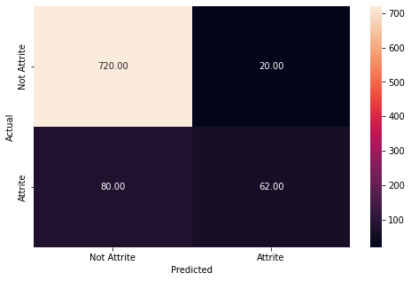

|  | 0 |
| --- | --- |
| OverTime | 0.915687 |
| BusinessTravel_Travel_Frequently | 0.667244 |
| JobRole_Laboratory Technician | 0.576941 |
| YearsSinceLastPromotion | 0.555837 |
| MaritalStatus_Single | 0.548705 |
| YearsAtCompany | 0.547448 |
| Department_Sales | 0.480093 |
| NumCompaniesWorked | 0.476151 |
| BusinessTravel_Travel_Rarely | 0.394040 |
| JobRole_Human Resources | 0.379252 |
| DistanceFromHome | 0.355265 |
| JobRole_Sales Representative | 0.321824 |
| Department_Research & Development | 0.261823 |
| JobRole_Research Scientist | 0.228462 |
| MaritalStatus_Married | 0.202262 |
| JobRole_Sales Executive | 0.156810 |
| Gender_Male | 0.151589 |
| EducationField_Technical Degree | 0.150735 |
| JobRole_Manufacturing Director | 0.117495 |
| Education | 0.055820 |
| EducationField_Marketing | 0.044835 |
| JobRole_Manager | 0.038542 |
| HourlyRate | 0.020609 |
| MonthlyRate | 0.004901 |
| MonthlyIncome | -0.036988 |
| PerformanceRating | -0.037468 |
| PercentSalaryHike | -0.060421 |
| DailyRate | -0.061546 |
| JobLevel | -0.077543 |
| EducationField_Other | -0.108351 |
| StockOptionLevel | -0.117990 |
| EducationField_Life Sciences | -0.182198 |
| JobRole_Research Director | -0.232881 |
| TrainingTimesLastYear | -0.239647 |
| WorkLifeBalance | -0.240866 |
| EducationField_Medical | -0.252399 |
| RelationshipSatisfaction | -0.270593 |
| Age | -0.311922 |
| YearsWithCurrManager | -0.390584 |
| JobSatisfaction | -0.407941 |
| JobInvolvement | -0.413972 |
| EnvironmentSatisfaction | -0.424085 |
| YearsInCurrentRole | -0.498777 |
| TotalWorkingYears | -0.520462 |

```python
# Logistic regression
def log_regression():
    logistic_regression = LogisticRegression(max_iter=1000)
    logistic_regression.fit(x_train, y_train)
    y_pred = logistic_regression.predict(x_test)

    print(x_test)  # test dataset
    print(y_pred)  # predicted values

    print('Accuracy: ', metrics.accuracy_score(y_pred, y_test))
    metrics_score(y_test, y_pred)

    #printing the coefficients of logistic regression
    cols = x_train.columns
    coef_lg=logistic_regression.coef_
    return pd.DataFrame(coef_lg,columns=cols).T.sort_values(by=0,ascending=False)

log_regression()
```

meaning that these are the attributes that have the greatest positive effect on attrition rate (more people quit).

meaning that these are the attributes that have the greatest negative effect on attrition rate (increases retention).

## K-Nearest Neighbors

Another simple classifier that can be applied to this data set is the K-Nearest Neighbors model. Compared with logistic regression, it is not as straight forward to find the effect of various features, especially with higher dimensional inputs. While K-NN also cannot handle the categorical features out of the box, K-NN similarly handle them by converting the *n* members of a categorical feature into *n* binary features.

```python
class Model(object):
    '''
    Harness for training and evaluating models

    Author: Brian Truong
    '''

    def __init__(self, title, model, features, labels, test_partition_pct=0.3):
        '''
        @param title:              Title of the model
        @param model:              Model instance to use
        @param features:           Input features to use
        @param labels:             Output labels to use
        @param test_partition_pct: Percentage of the given data to use for testing
        '''

        self.title = title
        self.instance = model
        self.features = features
        self.labels = labels

        self.train_data, self.test_data, self.train_labels, self.test_labels = train_test_split(
            features,
            labels,
            test_size=test_partition_pct,
            random_state=1,
            stratify=labels
        )

    def evaluate(self):
        '''Fit and evaluate the model'''

        print(f'\n{"-" * 10} {self.title}\n')

        print(f'Features: {self.features.shape[1]}')
        print(f'Train data: {len(self.train_labels)}; Attrition: {np.sum(self.train_labels)}')
        print(f'Test data: {len(self.test_labels)}; Attrition: {np.sum(self.test_labels)}')

        # Run model
        self.instance.fit(self.train_data, self.train_labels)
        print(f'\nModel hyperparameters:\n{json.dumps(self.instance.get_params(), indent=4)}')
        print(f'\nModel accuracy: {self.instance.score(self.test_data, self.test_labels)}\n')

        # Generate confusion matrix
        predictions = self.instance.predict(self.test_data)
        metrics_score(self.test_labels, predictions)

    def get_features_correlation(self):
        '''Get the features correlation matrix'''

        correlation = np.abs(self.features.corr())
        return correlation.style.background_gradient(cmap='coolwarm')

    def display_roc_curve(self, ax=None):
        '''
        Display the precision recall curve

        @param ax: (Optional) Matplotlib axis object to plot with
        '''

        axis = ax
        if not axis:
            _, axis = plt.subplots()

        probabilities = self.instance.predict_proba(self.test_data)[:, 1]
        false_pos_rate, true_pos_rate, thresholds = roc_curve(self.test_labels, probabilities)

        axis.plot(false_pos_rate, true_pos_rate, color='orange', label='ROC')
        axis.plot([0, 1], [0, 1], linestyle='--')
        axis.set_xlabel('False Positive Rate')
        axis.set_ylabel('True Positive Rate')
        axis.set_title(f'{self.title}: ROC curve')

    def get_grid_search_results(self, search_params, top=10):
        '''
        Pretty print the GridSearchCV results, and return the best params

        @param search_params: Dictionary of hyperparameter values to search with
        @param top:           (Optional) Number of top configurations to display

        @return: Best paramters
        '''
        model = GridSearchCV(self.instance, search_params, cv=5, scoring='accuracy')
        model.fit(self.train_data, self.train_labels)

        print(f'Best params: {model.best_params_}\nTop {top} configurations:')

        accuracies = pd.DataFrame(model.cv_results_)\
                       .filter(regex='(^param_)|mean_test_score',axis=1)\
                       .nlargest(top, columns=['mean_test_score'])
        display(accuracies)

        return model.best_params_

    def display_feature_importance(self):
        '''
        Plot the feature importance.
        ONLY WORKS FOR DECISION TREES.
        '''

        importances = pd.DataFrame(
            self.instance.feature_importances_,
            index=self.test_data.columns,
            columns=['Importance']
        ).sort_values(by='Importance',ascending=False)

        plt.figure(figsize=(13,13))
        sns.barplot(importances.Importance,importances.index)


def scatterplot_features(feature_a, feature_b, ax=None):
    '''
    Plot a scatterplot between two features

    @param feature_a: Feature to use as x-axis
    @param feature_b: Feature to use as y-axis
    @param ax: (Optional) Matplotlib axis object to plot with
    '''

    axis = ax
    if not axis:
        _, axis = plt.subplots()

    axis.scatter(
        df[feature_a][df['Attrition'] == 0],
        df[feature_b][df['Attrition'] == 0],
        marker='D',
        label='No'
    )
    axis.scatter(
        df[feature_a][df['Attrition'] == 1],
        df[feature_b][df['Attrition'] == 1],
        color='orange',
        label='Yes')

    axis.set_xlabel(feature_a)
    axis.set_ylabel(feature_b)
    axis.legend()
```

For the first K-NN model, all features were used to train the model, while setting `k=6` weighted by distance. This leads to a model accuracy of `~0.953`, with a very good ROC curve. Given the high dimensionality, this high performance wasn't really expected with such a simple distance-based model.

```
---------- K-NN All scalar

Features: 44
Train data: 2058; Attrition: 332
Test data: 882; Attrition: 142

Model hyperparameters:
{
    "algorithm": "auto",
    "leaf_size": 30,
    "metric": "minkowski",
    "metric_params": null,
    "n_jobs": null,
    "n_neighbors": 6,
    "p": 2,
    "weights": "distance"
}

Model accuracy: 0.9523809523809523

              precision    recall  f1-score   support

           0       0.96      0.98      0.97       740
           1       0.90      0.79      0.84       142

    accuracy                           0.95       882
   macro avg       0.93      0.89      0.91       882
weighted avg       0.95      0.95      0.95       882
```

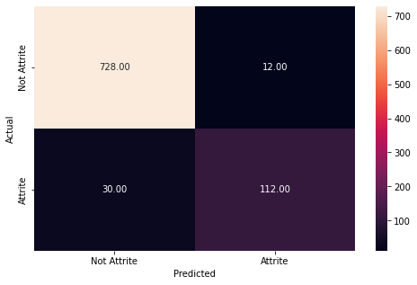

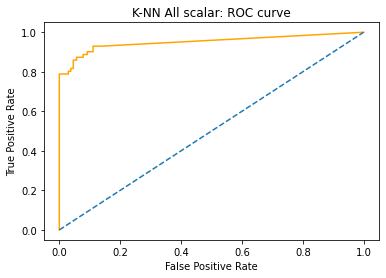

```python
# KNN using all scalar features without normalization
knn_all = Model(
    title='K-NN All scalar',
    model=KNeighborsClassifier(n_neighbors=6, weights='distance'),
    features=X_scaled,
    labels=Y
)
knn_all.evaluate()
knn_all.display_roc_curve()
```

Focusing on only the 19 relevant scalar features, this leads to a model accuracy of `~0.946`, with a very good ROC curve, a modest decrease over using all the features.

```
---------- K-NN All scalar

Features: 19
Train data: 2058; Attrition: 332
Test data: 882; Attrition: 142

Model hyperparameters:
{
    "algorithm": "auto",
    "leaf_size": 30,
    "metric": "minkowski",
    "metric_params": null,
    "n_jobs": null,
    "n_neighbors": 6,
    "p": 2,
    "weights": "distance"
}

Model accuracy: 0.9455782312925171

              precision    recall  f1-score   support

           0       0.96      0.98      0.97       740
           1       0.86      0.79      0.82       142

    accuracy                           0.95       882
   macro avg       0.91      0.88      0.90       882
weighted avg       0.94      0.95      0.94       882
```

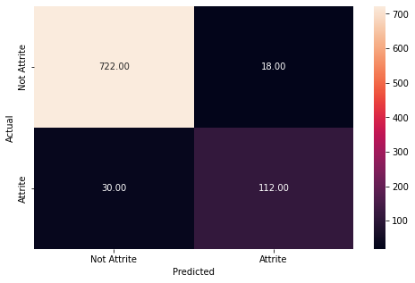

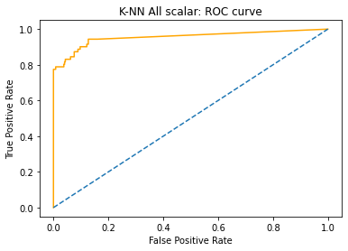

```python
# KNN using all scalar features without normalization
knn_all = Model(
    title='K-NN All scalar',
    model=KNeighborsClassifier(n_neighbors=6, weights='distance'),
    features=X_scaled.get(scalar_features),
    labels=Y
)
knn_all.evaluate()
knn_all.display_roc_curve()
```

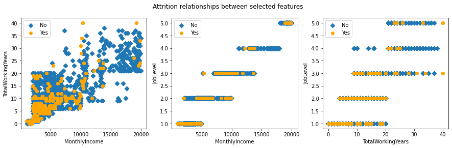

```python
def plot_reduced_features():
    fig, axs = plt.subplots(1, 3)
    fig.set_size_inches(15, 4)
    fig.suptitle('Attrition relationships between selected features')

    scatterplot_features('MonthlyIncome', 'TotalWorkingYears', ax=axs[0])
    scatterplot_features('MonthlyIncome', 'JobLevel', ax=axs[1])
    scatterplot_features('TotalWorkingYears', 'JobLevel', ax=axs[2])

plot_reduced_features()
```

In spite of this, the K-NN model is still able to maintain an accuracy of `~0.930`, suggesting that despite the overlap there is some sort of regularity in the way that the classes are distributed among these three features. Some further exploration on this iswould be warranted for the final report.

```
---------- K-NN Reduced

Features: 3
Train data: 2058; Attrition: 332
Test data: 882; Attrition: 142

Model hyperparameters:
{
    "algorithm": "auto",
    "leaf_size": 30,
    "metric": "minkowski",
    "metric_params": null,
    "n_jobs": null,
    "n_neighbors": 6,
    "p": 2,
    "weights": "distance"
}

Model accuracy: 0.9297052154195011

              precision    recall  f1-score   support

           0       0.97      0.95      0.96       740
           1       0.76      0.83      0.79       142

    accuracy                           0.93       882
   macro avg       0.86      0.89      0.87       882
weighted avg       0.93      0.93      0.93       882
```

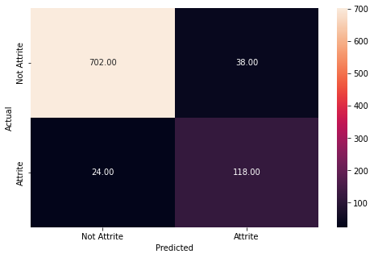

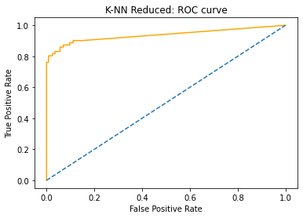

```python
# KNN using reduced features without normalization
knn_reduced = Model(
    title='K-NN Reduced',
    model=KNeighborsClassifier(n_neighbors=6, weights='distance'),
    features=X_scaled.get([
        'Age',
        'MonthlyIncome',
        'JobLevel'
    ]),
    labels=Y
)
knn_reduced.evaluate()
knn_reduced.display_roc_curve()
```

However, not all combinations of features leads to a highly accurate model. Choosing simply the various satisfaction metrics yields a much poorer performing model, indicating that employee satisfaction is not the end all be all of whether an employee attrites.

```
---------- K-NN Satisfaction

Features: 4
Train data: 2058; Attrition: 332
Test data: 882; Attrition: 142

Model hyperparameters:
{
    "algorithm": "auto",
    "leaf_size": 30,
    "metric": "minkowski",
    "metric_params": null,
    "n_jobs": null,
    "n_neighbors": 6,
    "p": 2,
    "weights": "distance"
}

Model accuracy: 0.8435374149659864

              precision    recall  f1-score   support

           0       0.86      0.98      0.91       740
           1       0.55      0.15      0.24       142

    accuracy                           0.84       882
   macro avg       0.70      0.57      0.58       882
weighted avg       0.81      0.84      0.80       882
```

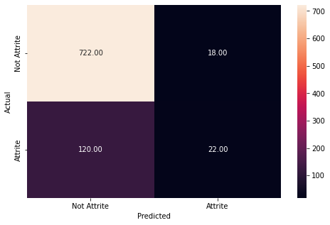

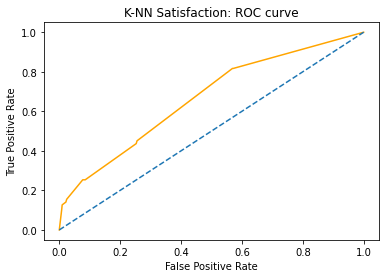

```python
# KNN using just satisfaction features without normalization
knn_satisfaction = Model(
    title='K-NN Satisfaction',
    model=KNeighborsClassifier(n_neighbors=6, weights='distance'),
    features=X_scaled.get([
        'EnvironmentSatisfaction',
        'JobSatisfaction',
        'WorkLifeBalance',
        'RelationshipSatisfaction',
    ]),
    labels=Y
)
knn_satisfaction.evaluate()
knn_satisfaction.display_roc_curve()
```

```
---------- K-NN Best UST features

Features: 5
Train data: 2058; Attrition: 332
Test data: 882; Attrition: 142

Model hyperparameters:
{
    "algorithm": "auto",
    "leaf_size": 30,
    "metric": "minkowski",
    "metric_params": null,
    "n_jobs": null,
    "n_neighbors": 6,
    "p": 2,
    "weights": "distance"
}

Model accuracy: 0.8560090702947846

              precision    recall  f1-score   support

           0       0.88      0.96      0.92       740
           1       0.59      0.33      0.43       142

    accuracy                           0.86       882
   macro avg       0.74      0.64      0.67       882
weighted avg       0.84      0.86      0.84       882
```

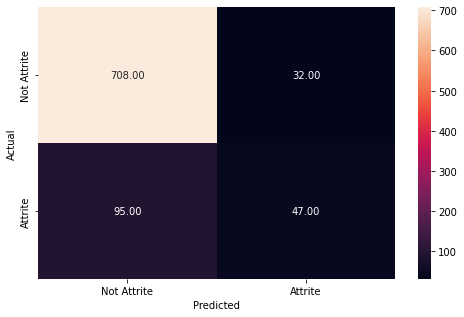

```
---------- K-NN Best RFE features

Features: 6
Train data: 2058; Attrition: 332
Test data: 882; Attrition: 142

Model hyperparameters:
{
    "algorithm": "auto",
    "leaf_size": 30,
    "metric": "minkowski",
    "metric_params": null,
    "n_jobs": null,
    "n_neighbors": 6,
    "p": 2,
    "weights": "distance"
}

Model accuracy: 0.8356009070294784

              precision    recall  f1-score   support

           0       0.86      0.96      0.91       740
           1       0.47      0.19      0.27       142

    accuracy                           0.84       882
   macro avg       0.67      0.57      0.59       882
weighted avg       0.80      0.84      0.80       882
```

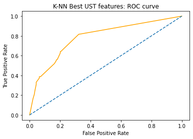

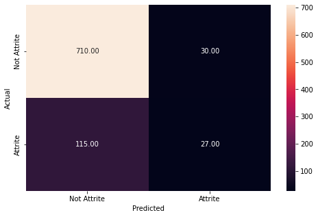

```
---------- K-NN Best PCA tuned features

Features: 4
Train data: 2058; Attrition: 332
Test data: 882; Attrition: 142

Model hyperparameters:
{
    "algorithm": "auto",
    "leaf_size": 30,
    "metric": "minkowski",
    "metric_params": null,
    "n_jobs": null,
    "n_neighbors": 6,
    "p": 2,
    "weights": "distance"
}

Model accuracy: 0.9387755102040817

              precision    recall  f1-score   support

           0       0.96      0.96      0.96       740
           1       0.81      0.80      0.81       142

    accuracy                           0.94       882
   macro avg       0.89      0.88      0.89       882
weighted avg       0.94      0.94      0.94       882
```

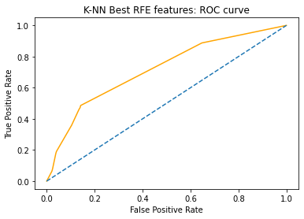

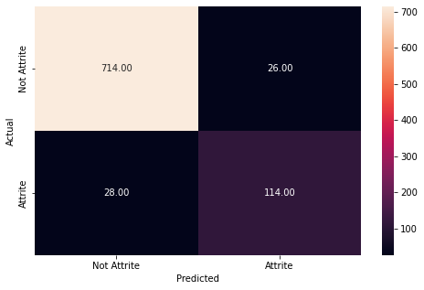

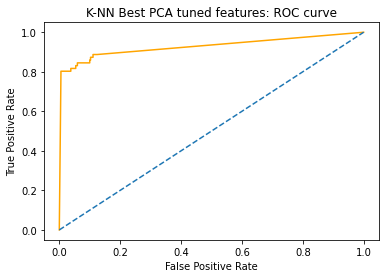

```python
# KNN using best features from Univariate Statistical Tests
knn_tuned_features_ust = Model(
    title='K-NN Best UST features',
    model=KNeighborsClassifier(n_neighbors=6, weights='distance'),
    features=X_scaled.get([
        'OverTime',
        'TotalWorkingYears',
        'JobLevel',
        'MaritalStatus_Single',
        'MaritalStatus_Married'
    ]),
    labels=Y
)
knn_tuned_features_ust.evaluate()
knn_tuned_features_ust.display_roc_curve()

# KNN using best features from RFE
knn_tuned_features_rfe = Model(
    title='K-NN Best RFE features',
    model=KNeighborsClassifier(n_neighbors=6, weights='distance'),
    features=X_scaled.get([
        'BusinessTravel_Travel_Frequently',
        'BusinessTravel_Travel_Rarely',
        'JobInvolvement',
        'MaritalStatus_Single',
        'MaritalStatus_Married',
        'OverTime'
    ]),
    labels=Y
)
knn_tuned_features_rfe.evaluate()
knn_tuned_features_rfe.display_roc_curve()

# KNN using best features from PCA
knn_tuned_features_pca = Model(
    title='K-NN Best PCA tuned features',
    model=KNeighborsClassifier(n_neighbors=6, weights='distance'),
    features=X_scaled.get([
        'OverTime',
        'Age',
        'MonthlyIncome',
        'TotalWorkingYears'
    ]),
    labels=Y
)
knn_tuned_features_pca.evaluate()
knn_tuned_features_pca.display_roc_curve()
```